# Naive Bayes Classifier

Diego J. Bodas Sagi

15 October 2017

# 1 Introduction

In machine learning, **Naive Bayes Classifiers** are a family of simple probabilistic classifiers based on applying **Bayes’ theorem** with strong (*naive*) independence assumptions between the features. Naive Bayes classifiers are highly scalable, requiring a number of parameters linear in the number of variables (features/predictors) in a learning problem (Wikipedia - Naive Bayes Classifier (2017)).

Independent events are those which, upon occurrence, do not affect the probability of another event occurring. An example would be a child in Madrid scoring a goal at school and me eating pasta at the same day. Dependent events are those which, upon occurrence, affect the probability of another event occurring. An example would be getting drunk one night and suffering headaches the following day. The more you drink the greater your chance of suffering a headache the following day. When two or more events are mutually exclusive, they cannot occur simultaneously. The probility is zero. I.e., It is imposible to be on holidays in Cantabria and in Mexico at the same time. These two outcomes are mutually exclusive.

The Naive Bayes Classifier are based on the famous Naive Bayes’ Theorem:

$P(A|B) = \frac{P(A \cap B)}{P(B)} = \frac{P(A)P(B|A)}{P(B)}$

To understand this, consider A as outcome and B and evidence. It is with this formula that the Naive Bayes classifier calculates conditional probabilities for a class outcome given prior information or evidence (our attributes in this case). The reason it is termed “naive” is because we assume independence between attributes when in reality they may be dependent in some way.

# 2 Probabilistic model

When we have a vector, we have to use the chain rule and use some maths:

$P(C_{k},x_{1},\dots ,x_{n}) =P(x_{1}\mid x_{2},\dots ,x_{n},C_{k})P(x_{2},\dots ,x_{n},C_{k})\\ =P(x_{1}\mid x_{2},\dots ,x_{n},C_{k})P(x_{2}\mid x_{3},\dots ,x_{n},C_{k})P(x_{3},\dots ,x_{n},C_{k})\\ =\dots \\ =P(x_{1}\mid x_{2},\dots ,x_{n},C_{k})P(x_{2}\mid x_{3},\dots ,x_{n},C_{k})\dots P(x_{n-1}\mid x_{n},C_{k})P(x_{n}\mid C_{k})P(C_{k})$

# 3 Hands-on

Let’s play with Naive Bayes Classification step by step example (getting our hands dirty).

Get the data

```r
#---------- load library ----------
if("mlbench" %in% rownames(installed.packages()) == FALSE) {install.packages("mlbench", dependencies = TRUE)}
library('mlbench')

# load data
data(BostonHousing2)

# info about the data
str(BostonHousing2)
```

```
## 'data.frame':    506 obs. of  19 variables:
##  $ town   : Factor w/ 92 levels "Arlington","Ashland",..: 54 77 77 46 46 46 69 69 69 69 ...
##  $ tract  : int  2011 2021 2022 2031 2032 2033 2041 2042 2043 2044 ...
##  $ lon    : num  -71 -71 -70.9 -70.9 -70.9 ...
##  $ lat    : num  42.3 42.3 42.3 42.3 42.3 ...
##  $ medv   : num  24 21.6 34.7 33.4 36.2 28.7 22.9 27.1 16.5 18.9 ...
##  $ cmedv  : num  24 21.6 34.7 33.4 36.2 28.7 22.9 22.1 16.5 18.9 ...
##  $ crim   : num  0.00632 0.02731 0.02729 0.03237 0.06905 ...
##  $ zn     : num  18 0 0 0 0 0 12.5 12.5 12.5 12.5 ...
##  $ indus  : num  2.31 7.07 7.07 2.18 2.18 2.18 7.87 7.87 7.87 7.87 ...
##  $ chas   : Factor w/ 2 levels "0","1": 1 1 1 1 1 1 1 1 1 1 ...
##  $ nox    : num  0.538 0.469 0.469 0.458 0.458 0.458 0.524 0.524 0.524 0.524 ...
##  $ rm     : num  6.58 6.42 7.18 7 7.15 ...
##  $ age    : num  65.2 78.9 61.1 45.8 54.2 58.7 66.6 96.1 100 85.9 ...
##  $ dis    : num  4.09 4.97 4.97 6.06 6.06 ...
##  $ rad    : int  1 2 2 3 3 3 5 5 5 5 ...
##  $ tax    : int  296 242 242 222 222 222 311 311 311 311 ...
##  $ ptratio: num  15.3 17.8 17.8 18.7 18.7 18.7 15.2 15.2 15.2 15.2 ...
##  $ b      : num  397 397 393 395 397 ...
##  $ lstat  : num  4.98 9.14 4.03 2.94 5.33 ...
```

```r
summary(BostonHousing2)
```

```
##                 town         tract           lon              lat
##  Cambridge        : 30   Min.   :   1   Min.   :-71.29   Min.   :42.03
##  Boston Savin Hill: 23   1st Qu.:1303   1st Qu.:-71.09   1st Qu.:42.18
##  Lynn             : 22   Median :3394   Median :-71.05   Median :42.22
##  Boston Roxbury   : 19   Mean   :2700   Mean   :-71.06   Mean   :42.22
##  Newton           : 18   3rd Qu.:3740   3rd Qu.:-71.02   3rd Qu.:42.25
##  Somerville       : 15   Max.   :5082   Max.   :-70.81   Max.   :42.38
##  (Other)          :379
##       medv           cmedv            crim                zn
##  Min.   : 5.00   Min.   : 5.00   Min.   : 0.00632   Min.   :  0.00
##  1st Qu.:17.02   1st Qu.:17.02   1st Qu.: 0.08204   1st Qu.:  0.00
##  Median :21.20   Median :21.20   Median : 0.25651   Median :  0.00
##  Mean   :22.53   Mean   :22.53   Mean   : 3.61352   Mean   : 11.36
##  3rd Qu.:25.00   3rd Qu.:25.00   3rd Qu.: 3.67708   3rd Qu.: 12.50
##  Max.   :50.00   Max.   :50.00   Max.   :88.97620   Max.   :100.00
##
##      indus       chas         nox               rm             age
##  Min.   : 0.46   0:471   Min.   :0.3850   Min.   :3.561   Min.   :  2.90
##  1st Qu.: 5.19   1: 35   1st Qu.:0.4490   1st Qu.:5.886   1st Qu.: 45.02
##  Median : 9.69           Median :0.5380   Median :6.208   Median : 77.50
##  Mean   :11.14           Mean   :0.5547   Mean   :6.285   Mean   : 68.57
##  3rd Qu.:18.10           3rd Qu.:0.6240   3rd Qu.:6.623   3rd Qu.: 94.08
##  Max.   :27.74           Max.   :0.8710   Max.   :8.780   Max.   :100.00
##
##       dis              rad              tax           ptratio
##  Min.   : 1.130   Min.   : 1.000   Min.   :187.0   Min.   :12.60
##  1st Qu.: 2.100   1st Qu.: 4.000   1st Qu.:279.0   1st Qu.:17.40
##  Median : 3.207   Median : 5.000   Median :330.0   Median :19.05
##  Mean   : 3.795   Mean   : 9.549   Mean   :408.2   Mean   :18.46
##  3rd Qu.: 5.188   3rd Qu.:24.000   3rd Qu.:666.0   3rd Qu.:20.20
##  Max.   :12.127   Max.   :24.000   Max.   :711.0   Max.   :22.00
##
##        b              lstat
##  Min.   :  0.32   Min.   : 1.73
##  1st Qu.:375.38   1st Qu.: 6.95
##  Median :391.44   Median :11.36
##  Mean   :356.67   Mean   :12.65
##  3rd Qu.:396.23   3rd Qu.:16.95
##  Max.   :396.90   Max.   :37.97
##
```

The dataframe BostonHousing contains the original data by Harrison and Rubinfeld (1978), the dataframe BostonHousing2 includes additional spatial information. Get more information about this dataset in Leisch and Dimitriadou (2015). The target variable is *medv*, representing the median value of owner-occupied homes in USD 1000’s.

We categorize the age for training purposes

```r
# Using cut
BostonHousing2$age_range <- cut(BostonHousing2$age, breaks = c(-Inf, 20, 30, 40, 60, Inf),
                       labels = c(0, 1, 2, 3, 4),
                       right = FALSE)
BostonHousing2$age <- NULL
```

For a simple example, we transform the *medv* variable into a simpler one meaning under o above the mean.

```r
BostonHousing2$homes_range <- as.factor(ifelse(BostonHousing2$medv <
                                                 ((max(BostonHousing2$medv) - min(BostonHousing2$medv))/2), 0, 1))
# delete medv variable
BostonHousing2$medv <- NULL
```

Examine the new variable

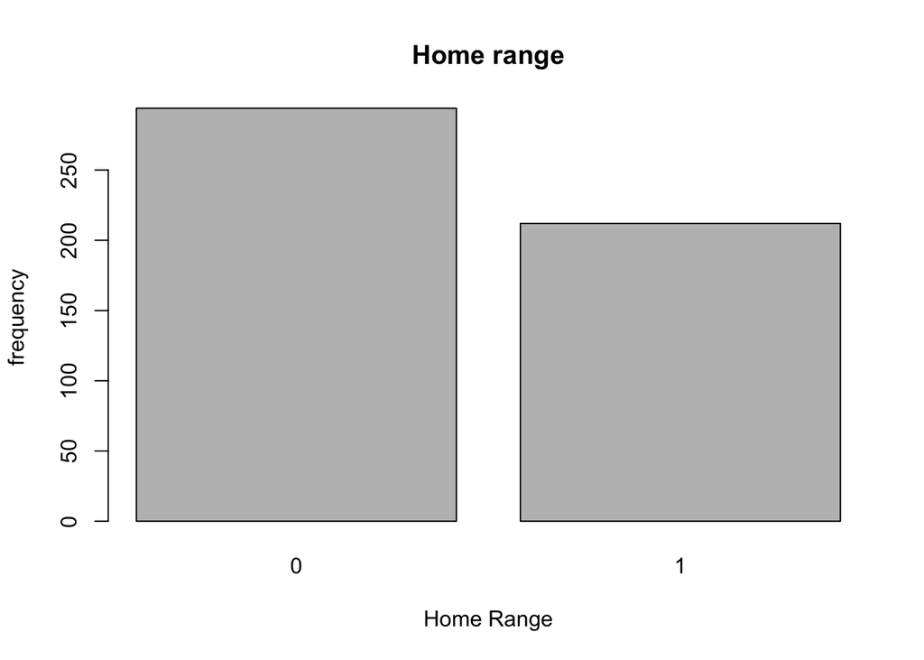

```r
plot(BostonHousing2$homes_range)
title(main = "Home range", xlab = "Home Range", ylab = "frequency")
```

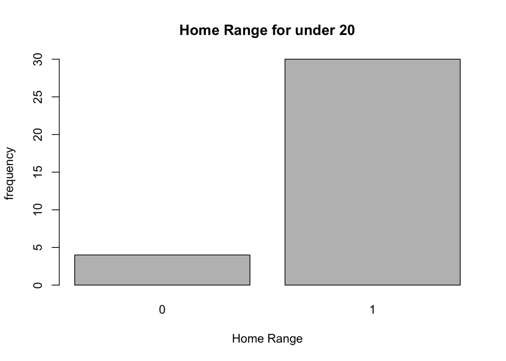

```r
#by age
plot(BostonHousing2[BostonHousing2$age_range == 0, ncol(BostonHousing2)])
title(main = "Home Range for under 20", xlab = "Home Range", ylab = "frequency")
```

Do not forget the quality control

```r
ages_na <- which(is.na(BostonHousing2$age_range) == TRUE)
homes_na <- which(is.na(BostonHousing2$homes_range) == TRUE)
# no NAs in this case
```

We have already explired the dataset. Now, compute the conditional probability of $homeRange = 0$ when $ageRange = 4 (senior)$

$P(homeRange = 0 | ageRange = 4) = \frac{P(homeRange = 0 \cap ageRange = 4)}{P(ageRange = 4)}$

```r
# Exercise:
# Compute: P(homeRange = 0 | ageRange = 4)
```

When we have to take into account all the variables the maths get complex. Luckily, the *e1071* R package is available to help us. But first, prepare the test and training sets.

```r
# divide into test and training sets
# create new col "train"" and assign 1 or 0 in 80/20 proportion via random uniform dist
BostonHousing2[, "train"] <- ifelse(runif(nrow(BostonHousing2)) < 0.80, 1, 0)
# get col number of train / test indicator column (needed later)
trainColNum <- grep("train", names(BostonHousing2))
# separate training and test sets and remove training column before modeling
trainBostonHousing2 <-BostonHousing2[BostonHousing2$train == 1,-trainColNum]
testBostonHousing2 <- BostonHousing2[BostonHousing2$train == 0,-trainColNum]
```

Now, do the maths using the *e1071* package

```r
if("e1071" %in% rownames(installed.packages()) == FALSE) {install.packages("e1071", dependencies = TRUE)}
library('e1071')

naive_bayes_model <- naiveBayes(homes_range ~., data = trainBostonHousing2)
naive_bayes_model
```

```
##
## Naive Bayes Classifier for Discrete Predictors
##
## Call:
## naiveBayes.default(x = X, y = Y, laplace = laplace)
##
## A-priori probabilities:
## Y
##         0         1
## 0.5753769 0.4246231
##
## Conditional probabilities:
##    town
## Y     Arlington     Ashland     Bedford     Belmont     Beverly
##   0 0.000000000 0.008733624 0.000000000 0.000000000 0.004366812
##   1 0.035502959 0.000000000 0.005917160 0.041420118 0.005917160
##    town
## Y   Boston Allston-Brighton Boston Back Bay Boston Beacon Hill
##   0             0.017467249     0.008733624        0.000000000
##   1             0.017751479     0.017751479        0.011834320
##    town
## Y   Boston Charlestown Boston Dorchester Boston Downtown
##   0        0.021834061       0.043668122     0.021834061
##   1        0.000000000       0.000000000     0.011834320
##    town
## Y   Boston East Boston Boston Forest Hills Boston Hyde Park
##   0        0.043668122         0.021834061      0.013100437
##   1        0.005917160         0.005917160      0.000000000
##    town
## Y   Boston Mattapan Boston North End Boston Roxbury Boston Savin Hill
##   0     0.017467249      0.004366812    0.061135371       0.074235808
##   1     0.005917160      0.000000000    0.000000000       0.000000000
##    town
## Y   Boston South Boston Boston West Roxbury   Braintree   Brookline
##   0         0.039301310         0.004366812 0.008733624 0.000000000
##   1         0.000000000         0.017751479 0.017751479 0.065088757
##    town
## Y    Burlington   Cambridge      Canton     Chelsea    Cohasset
##   0 0.004366812 0.056768559 0.004366812 0.021834061 0.000000000
##   1 0.011834320 0.065088757 0.011834320 0.000000000 0.005917160
```

[output cut: 122 more lines]

```
##
##    b
## Y       [,1]      [,2]
##   0 340.3866 108.22413
##   1 384.0597  32.84479
##
##    lstat
## Y        [,1]     [,2]
##   0 16.471878 6.463318
##   1  7.299053 3.460587
##
##    age_range
## Y            0          1          2          3          4
##   0 0.01310044 0.01746725 0.04803493 0.13973799 0.78165939
##   1 0.14792899 0.11242604 0.10650888 0.17159763 0.46153846
```

```r
summary(naive_bayes_model)
```

```
##         Length Class  Mode
## apriori  2     table  numeric
## tables  18     -none- list
## levels   2     -none- character
## call     4     -none- call
```

```r
str(naive_bayes_model)
```

```
## List of 4
##  $ apriori: 'table' int [1:2(1d)] 229 169
##   ..- attr(*, "dimnames")=List of 1
##   .. ..$ Y: chr [1:2] "0" "1"
##  $ tables :List of 18
##   ..$ town     : table [1:2, 1:92] 0 0.0355 0.00873 0 0 ...
##   .. ..- attr(*, "dimnames")=List of 2
##   .. .. ..$ Y   : chr [1:2] "0" "1"
##   .. .. ..$ town: chr [1:92] "Arlington" "Ashland" "Bedford" "Belmont" ...
##   ..$ tract    : num [1:2, 1:2] 2236 3272 1391 1135
##   .. ..- attr(*, "dimnames")=List of 2
##   .. .. ..$ Y    : chr [1:2] "0" "1"
##   .. .. ..$ tract: NULL
##   ..$ lon      : num [1:2, 1:2] -71.0405 -71.0748 0.0612 0.0851
##   .. ..- attr(*, "dimnames")=List of 2
##   .. .. ..$ Y  : chr [1:2] "0" "1"
##   .. .. ..$ lon: NULL
##   ..$ lat      : num [1:2, 1:2] 42.2157 42.2196 0.0563 0.0682
##   .. ..- attr(*, "dimnames")=List of 2
##   .. .. ..$ Y  : chr [1:2] "0" "1"
##   .. .. ..$ lat: NULL
##   ..$ cmedv    : num [1:2, 1:2] 16.88 30.12 4.24 8.25
##   .. ..- attr(*, "dimnames")=List of 2
##   .. .. ..$ Y    : chr [1:2] "0" "1"
##   .. .. ..$ cmedv: NULL
##   ..$ crim     : num [1:2, 1:2] 5.733 0.915 10.715 2.24
##   .. ..- attr(*, "dimnames")=List of 2
##   .. .. ..$ Y   : chr [1:2] "0" "1"
##   .. .. ..$ crim: NULL
##   ..$ zn       : num [1:2, 1:2] 4.23 19.72 14.26 28.58
##   .. ..- attr(*, "dimnames")=List of 2
##   .. .. ..$ Y : chr [1:2] "0" "1"
##   .. .. ..$ zn: NULL
##   ..$ indus    : num [1:2, 1:2] 14.06 7.46 6.39 5.74
##   .. ..- attr(*, "dimnames")=List of 2
##   .. .. ..$ Y    : chr [1:2] "0" "1"
##   .. .. ..$ indus: NULL
##   ..$ chas     : table [1:2, 1:2] 0.9389 0.9172 0.0611 0.0828
##   .. ..- attr(*, "dimnames")=List of 2
##   .. .. ..$ Y   : chr [1:2] "0" "1"
```

[output cut: 25 more lines]

```
##   ..$ b        : num [1:2, 1:2] 340.4 384.1 108.2 32.8
##   .. ..- attr(*, "dimnames")=List of 2
##   .. .. ..$ Y: chr [1:2] "0" "1"
##   .. .. ..$ b: NULL
##   ..$ lstat    : num [1:2, 1:2] 16.47 7.3 6.46 3.46
##   .. ..- attr(*, "dimnames")=List of 2
##   .. .. ..$ Y    : chr [1:2] "0" "1"
##   .. .. ..$ lstat: NULL
##   ..$ age_range: table [1:2, 1:5] 0.0131 0.1479 0.0175 0.1124 0.048 ...
##   .. ..- attr(*, "dimnames")=List of 2
##   .. .. ..$ Y        : chr [1:2] "0" "1"
##   .. .. ..$ age_range: chr [1:5] "0" "1" "2" "3" ...
##  $ levels : chr [1:2] "0" "1"
##  $ call   : language naiveBayes.default(x = X, y = Y, laplace = laplace)
##  - attr(*, "class")= chr "naiveBayes"
```

Evaluate the model

```r
naive_bayes_test_predict <- predict(naive_bayes_model, testBostonHousing2[, -ncol(testBostonHousing2)])
#confusion matrix
table(pred = naive_bayes_test_predict, true = testBostonHousing2$homes_range)
```

```
##     true
## pred  0  1
##    0 45  3
##    1 20 40
```

Correct predictions

```r
#fraction of correct predictions
mean(naive_bayes_test_predict == testBostonHousing2$homes_range)
```

```
## [1] 0.787037
```

Bad or good result?

# 4 Assignment

1. Encapsulate the code creating **functions**
2. Test more executions (remember we are using a random function to create the training and test set)
3. Test other training fractions (0.6, 0.7, 0.8, 0.9)
4. Try out for yourself, create new ranges, convert formats to factor… How to improve the results? A tournament is open
5. Try this technique with the dataset from Kaggle (2017) challenge

Use the RMarkdown format

# References

Harrison, D., and D.L. Rubinfeld. 1978. “Hedonic Prices and the Demand for Clean Air.” *Journal of Environmental Economics and Management* 5. Elsevier: 81–102.

Kaggle. 2017. “Give Me Some Credit.” https://www.kaggle.com/c/GiveMeSomeCredit.

Leisch, Friedrich, and Evgenia Dimitriadou. 2015. “Package ‘Mlbench’.” https://cran.r-project.org/web/packages/mlbench/mlbench.pdf.

Wikipedia - Naive Bayes Classifier. 2017. “Naive Bayes Classifier.” https://en.wikipedia.org/wiki/Naive_Bayes_classifier.